# Машинное обучение. ВМК МГУ

# Практическое задание 3: Линейные модели: регрессия

## Уровень: **Исследовательский (Research)**

# О формате сдачи

🔷 **При решении ноутбука используйте данный шаблон**

```
✅ Можно добавлять новые ячейки любых типов
❌ Не нужно удалять текстовые ячейки c разметкой частей ноутбука и формулировками заданий
```

🔷 **При оценивании задач учитывается код**

```
✅ Задания, в которых необходим код, обычно помечаются фразами "Your code here"/"Ваш код" и аналогичными
❌ Ответы на вопросы без сопутствующего кода оцениваются в 0 баллов
❌ Наличе работоспособного кода в ноутбуке, если на сказано иного, обязательно
```

🔷 **При оценивании задач учитываются выводы**

```
✅ Задания, в которых необходимы выводы, обычно помечаются фразами Вывод"/"Ответ на вопрос"/"Ваш текст" и аналогичными
✅ Обычно выводы подразумевают под собой текстовый ответ (можно писать markdown, latex).
✅ Сопутствующие изображения, графики, таблички - приветствуются!
❌ При отсутствии выводов задание не засчитается на полный балл
```

Цель данного задания:

- Узнать, что такое переобучение и как с ним бороться в линейных моделях;
- Понять, чем отличаются разные регуляризаторы;
- Научиться решать задачу регрессии линейными моделями.

**Примерное время выполнения (execution time/время выполнения, если нажать run all) всех ячеек ноутбука при правильной реализации: 7 минут **

# Подготовка рабочей среды

Сначала установим нужные нам версии библиотек. Мы гарантируем, что в данных версиях задание будет корректно отрабатывать.

После установки нужных версий, **возможно,** нужно перезагрузить среду (runtime), но скорее всего вам это не понадобится

На скачивание файла и установку понадобится не более 5 минут.

**Важно!**

Устанавливать нужные версии нужно каждый раз, когда создается новый рантайм. Например, если вы 2 часа подряд делаете это задание, то подготовить библиотеки достаточно 1 раз. Но если вы, например, начали в понедельник, затем закрыли/выключили ноутбук, то при продолжении в среду, вам нужно будет запустить рантайм заново и следовательно заново установить библиотеки.

**Важно!** Если вы предпочитаете делать практические задания на своем личном ноутбуке, то проверьте, что вы установили рабочее окружение в соответствии с гайдом.pdf)

```python
! curl https://raw.githubusercontent.com/MSU-ML-COURSE/ML-COURSE-25-26/refs/heads/master/requirements/requirements.txt -o ./requirements_2025_26_for_colab_small.txt
! pip install -q -r ./requirements_2025_26_for_colab_small.txt
```

[output not shown]

Проверим версию библиотеки:

```python
import catboost
assert(catboost.__version__ == '1.2.8')
```

Теперь можно приступать к выполнению задания! :)

```python
import numpy as np
import pandas as pd
import matplotlib.pyplot as plt
import seaborn as sns
import warnings
warnings.simplefilter("ignore")
sns.set(style="darkgrid")
%matplotlib inline
```

## Линейная регрессия и регуляризация

Напомним, что линейная регрессия — это модель следующего вида: $$a(x) = \langle w, x \rangle + b$$ где $w \in \mathbb{R}^d$, $b \in \mathbb{R}$. Обучить линейную регрессию — значит найти $w$ и $b$.

В модели линейной регрессии с $l_2$ регуляризацией мы оптимизируем следующий функционал:

$\frac{1}{N} \cdot ∑_{i=1}^M (w_1 \cdot x_{i1} + \dots w_n \cdot x_{in} + b - y_i)^2 + \frac{\alpha}{2} \cdot \left( w_1^2 + \dots + w_n^2 \right) \rightarrow \min_{w_1, \dots, w_n, b}$

В модели линейной регрессии с $l_1$ регуляризацией мы оптимизируем следующий функционал:

$\frac{1}{N} \cdot ∑_{i=1}^M (w_1 \cdot x_{i1} + \dots w_n \cdot x_{in} + b - y_i)^2 + \alpha \cdot \left( |w_1| + \dots + |w_n| \right) \rightarrow \min_{w_1, \dots, w_n, b}$

### **Задание 1 [1 балл]**

Почему при обучении линейных моделей, коэффициент $b$ не регуляризуется? Дайте ответ с опорой на лекции. Возможно вам также поможет картика из базовой части

**Ваши выводы тут:**  
Свободный член b исключается из регуляризации по двум ключевым причинам:

Не причина переобучения: Переобучение вызывается чрезмерно большими весами w, которые делают модель слишком чувствительной к отдельным признакам. Коэффициент b отвечает лишь за смещение модели в целом и не влияет на эту чувствительность.

Нежелательный эффект: Регуляризация b принудительно смещала бы гиперплоскость к началу координат, что исказило бы предсказания и ухудшило качество модели, не решая проблему переобучения.

Рассмотрим модель линейной регрессии с $l_2$ регуляризацией. В sklearn эта модель реализована посредством класса Ridge. В нём есть методы fit и predict. Первый принимает на вход обучающую выборку и вектор целевых переменных и обучает модель, второй, будучи вызванным после обучения модели, возвращает предсказание на выборке.

Сгенерируем случайные данные. Пусть $x$ будет обычным числом из равномерного распределения, а $𝑦=0.5 \cdot x + 0.1$ — целевая переменная. При этом наблюдаем мы $\overline{y} = y + \varepsilon,~\varepsilon \sim N(0, 0.01)$. Добавим в данные к переменной $x$ её же умноженную на $3$. То есть, теперь у нас два признака $x_1$ и $x_2 = 3 \cdot x_1$.

Поскольку $y = c \cdot 0.5 \cdot x_1 + \frac{1 - c}{6} \cdot x_2 + 0.1$, где $c$ любое сколь угодно большое вещественное число. То, как мы могли убедиться в базовой части, без регуляризации есть риск выучить очень большие веса.

Посмотрим, как меняется значения весов, в зависимости от значения коэффициента регуляризации.

```python
from sklearn.linear_model import Ridge
```

```python
np.random.seed(1)
X = np.random.uniform(0, 1, 100)
Y = X * 0.5 + 0.1 + np.random.randn(100) * 0.1

X3 = np.hstack((X[:, None], 3 * X[:, None]))
Y3 = X3[:, 0] * 0.5 + 0.1 + np.random.randn(100) * 0.1
```

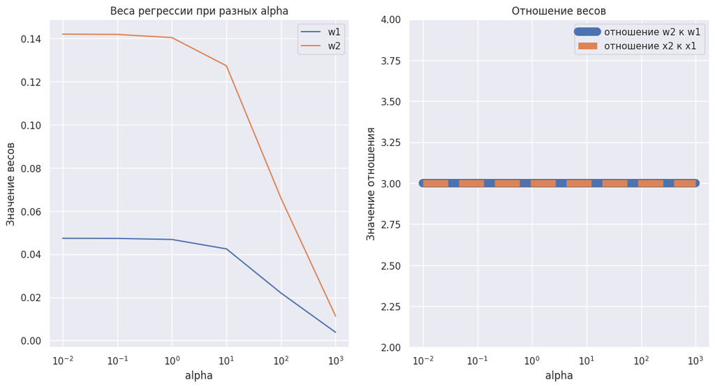

```python
w1 = []
w2 = []

alphas = [0.01, 0.1, 1, 10, 100, 1000]

for alpha in alphas:
    reg = Ridge(alpha=alpha)
    reg.fit(X3, Y3)
    w1.append(reg.coef_[0])
    w2.append(reg.coef_[1])

w1 = np.array(w1)
w2 = np.array(w2)

fig, axs = plt.subplots(figsize=(14, 7), ncols=2)
axs[0].plot(alphas, w1, label="w1")
axs[0].plot(alphas, w2, label="w2")
axs[0].set_xscale("log")
axs[0].set_title("Веса регрессии при разных alpha")
axs[0].set_xlabel("alpha")
axs[0].set_ylabel("Значение весов")
axs[0].legend()
axs[1].plot(alphas, w2 / w1, label="отношение w2 к w1", linewidth=10)
axs[1].plot([0.01, 1000], [3, 3], label="отношение x2 к x1", linestyle="--", linewidth=8)
axs[1].set_xscale("log")
axs[1].set_ylim(2,4)
axs[1].set_xlabel("alpha")
axs[1].set_ylabel("Значение отношения")
axs[1].set_title("Отношение весов")
axs[1].legend()
plt.show()
```

### **Задание 2 [2 баллa]**

Как думаете, почему отношение между весами постоянно? (подсказка, необходимо выписать функцию потерь и посчитать производные по весам)

**Ваши выводы тут:**  
Отношение между весами $w_2/w_1$ остается постоянным из-за особенностей оптимизации l2-регуляризации в условиях линейной зависимости признаков.

Рассмотрим функцию потерь для Ridge-регрессии:

$L(w_1, w_2, b) = \frac{1}{N}\sum_{i=1}^N (w_1x_{i1} + w_2x_{i2} + b - y_i)^2 + \frac{\alpha}{2}(w_1^2 + w_2^2)$

В нашем случае $x_2 = 3x_1$:

$L(w_1, w_2, b) = \frac{1}{N}\sum_{i=1}^N ((w_1 + 3w_2)x_{i1} + b - y_i)^2 + \frac{\alpha}{2}(w_1^2 + w_2^2)$

Пусть $u = w_1 + 3w_2$ - это эффективный вес для признака $x_1$. Первое слагаемое (MSE) зависит только от $u$, а не от отдельных $w_1$ и $w_2$.

Использую метод множителей Лагранжа:

$\mathcal{L} = w_1^2 + w_2^2 + \lambda(u - w_1 - 3w_2)$

Беру производные и приравниваю к нулю:

$\begin{cases} \frac{\partial \mathcal{L}}{\partial w_1} = 2w_1 - \lambda = 0; \\ \frac{\partial \mathcal{L}}{\partial w_2} = 2w_2 - 3\lambda = 0; \\ \frac{\partial \mathcal{L}}{\partial \lambda} = u - w_1 - 3w_2 = 0; \end{cases}$

Из первых двух уравнений: $w_1 = \frac{\lambda}{2}$, $w_2 = \frac{3\lambda}{2}$

Значит $\frac{w_2}{w_1} = \frac{\frac{3\lambda}{2}}{\frac{\lambda}{2}} = 3$

т.е. $\forall\alpha > 0$ оптимальное отношение весов $w_2/w_1$ будет равно отношению признаков $x_2/x_1 = 3$.

Заметим, что при $l_2$ регуляризации в данном примере веса получились пропорциональны значениям признаков. При этом, мы знаем, что оба признака взаимно однозначны, и прогноз можно делать только по одному из них. Для этого придумана $l_1$ регуляризация. В билиотеке sklearn линейная регрессия с $l_1$ регуляризацией реализована в классе Lasso

### **Задание 3 [2 баллa]**

Почему в нашем примере $l_1$ регуляризация приведёт к разреживанию весов? (подсказка, нужно опять подсчитать производную, но обратите внимание на дифференцируемость модуля).

**Ваши выводы тут:**  
В случае L1-регуляризации разреживание весов происходит из-за недифференцируемости функции модуля в нуле. В нашем примере с $x_2 = 3x_1$ L1-регуляризация приводит к обнулению одного из весов, чтобы минимизировать штраф.

Рассмотрим функцию потерь для Lasso-регрессии:

$L(w_1, w_2, b) = \frac{1}{N}\sum_{i=1}^N (w_1x_{i1} + w_2x_{i2} + b - y_i)^2 + \alpha (|w_1| + |w_2|)$

$x_2 = 3x_1$:

$L(w_1, w_2, b) = \frac{1}{N}\sum_{i=1}^N ((w_1 + 3w_2)x_{i1} + b - y_i)^2 + \alpha (|w_1| + |w_2|)$

$u = w_1 + 3w_2$ - эффективный вес. Первое слагаемое (MSE) зависит только от $u$, а регуляризационный член $\alpha (|w_1| + |w_2|)$ зависит от отдельных весов.

Функция $|w|$ недифферинцируема в нуле:

$w_j > 0$: производная $|w_j|$ равна $1$

$w_j < 0$: производная $|w_j|$ равна $-1$

$w_j = 0$: производная лежит в интервале $[-1, 1]$

т.к. признаки линейно зависимы то модель может предсказать $y$ используя только один признак.

Использую только $x_1$: $w_2 = 0$, $w_1 = u$, штраф регуляризации: $\alpha |u|$

Использую только $x_2$: $w_1 = 0$, $w_2 = u/3$, штраф регуляризации: $\alpha |u/3| = \alpha |u|/3$

$\alpha |u|/3 < \alpha |u|$ значит, второй сценарий дает меньший штраф и l1-регуляризация выберет $w_1 = 0$ и $w_2 = u/3$, чтобы минимизировать функцию потерь.

Получается, из-за л./з. признаков и свойств этой регуляризации, оптимизация приводит к обнулению веса $w_1$, так как признак $x_2$ имеет больший масштаб и для того же вклада в предсказание требует меньшего веса, что уменьшает штраф.

Добавим $l_1$ регуляризацию и посмотрим, как меняется значения весов, в зависимости от значения коэффициента регуляризации.

```python
from sklearn.linear_model import Lasso
```

```python
reg = Lasso(alpha=1., max_iter=1000, tol=1e-4)
reg.fit(X3, Y3)
print("Веса, при alpha = 1.")
print("w1:", reg.coef_[0], "\tw2:", reg.coef_[1])
print()

reg = Lasso(alpha=0.1, max_iter=1000, tol=1e-4)
reg.fit(X3, Y3)
print("Веса, при alpha = 0.1")
print("w1:", reg.coef_[0], "\tw2:", reg.coef_[1])
print()

reg = Lasso(alpha=0.01, max_iter=1000, tol=1e-4)
reg.fit(X3, Y3)
print("Веса, при alpha = 0.01")
print("w1:", reg.coef_[0], "\tw2:", reg.coef_[1])
print()

reg = Lasso(alpha=0.001, max_iter=1000, tol=1e-4)
reg.fit(X3, Y3)
print("Веса, при alpha = 0.001")
print("w1:", reg.coef_[0], "\tw2:", reg.coef_[1])
print()

reg = Lasso(alpha=0.0001, max_iter=1000, tol=1e-4)
reg.fit(X3, Y3)
print("Веса, при alpha = 0.0001")
print("w1:", reg.coef_[0], "\tw2:", reg.coef_[1])
print()

reg = Lasso(alpha=0.00001, max_iter=1000, tol=1e-4)
reg.fit(X3, Y3)
print("Веса, при alpha = 0.00001")
print("w1:", reg.coef_[0], "\tw2:", reg.coef_[1])
print()
```

```
Веса, при alpha = 1.
w1: 0.0 	w2: 0.0

Веса, при alpha = 0.1
w1: 0.0 	w2: 0.029684463509327023

Веса, при alpha = 0.01
w1: 0.0 	w2: 0.14506160917248503

Веса, при alpha = 0.001
w1: 0.0 	w2: 0.1565993237388008

Веса, при alpha = 0.0001
w1: 0.0 	w2: 0.1577530951954324

Веса, при alpha = 0.00001
w1: 0.3966873199145481 	w2: 0.025639365702912847
```

### **Задание 4 [2 баллa]**

Почему в итоге при $\alpha = 0.00001$ получились веса не равные нулю?

**Подсказка**

Обратите внимание на то, каким странным получился вес $w_2$

**Ваши выводы тут:**  
При крайне малом α = 0.00001 L1-регуляризация теряет свою основную функцию — создание разреженных моделей. Модель вырождается и ведет себя практически как нерегуляризованная линейная регрессия, что в условиях линейной зависимости признаков приводит к нестабильным и нелогичным с точки зрения L1-регуляризации результатам.

1. Дисбаланс между ошибкой и штрафом. Параметр α является множителем, определяющим "стоимость" каждого ненулевого веса. При α = 0.00001 штрафной член α(|w₁| + |w₂|) становится пренебрежимо малым по сравнению с основным слагаемым MSE.
2. Проблема вырожденности в условиях мультиколлинеарности. Ситуация: При x₂ = 3x₁ без регуляризации существует бесконечное число комбинаций (w₁, w₂), дающих одинаковый эффективный вес u = w₁ + 3w₂ и, следовательно, идентичное значение MSE. 3) Странное соотношение весов. Полученные веса $w_1 = 0.3967$, $w_2=0.0256$ выглядят нелогично, т.к. эффективный вес для $x_1$ - это $w_1+3w_2 = 0.3967+3*0.0256=0.4735$, что близко к истинному значению 0.5, но распределение между $w_1$ и $w_2$ не оптимально с точки зрения l1-регуляризации.

```python
#Ваш код здесь
```

В предущих блоках мы использовали модельные примеры, в которых $y$ зависел от $x$ линейно. Но так бывает далеко не всегда.

### **Задание 5 [1 баллa]**

Придумайте, сгенерируйте и визуализируйте пример, в котором линейная регрессия будет плохо классифицировать данные.

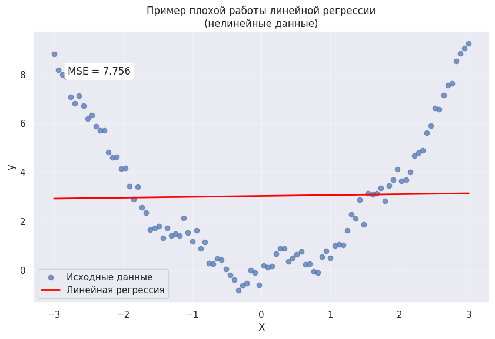

```
Линейная регрессия плохо справляется с этими данными, потому что:
1. Зависимость между X и y является квадратичной, а не линейной
2. Cинусоидальная составляющая создает дополнительные нелинейности
3. Линейная модель может аппроксимировать только прямую линию
4. Для таких данных лучше подходят полиномиальная регрессия или какие-нибудь еще нелинейные методы
```

```python
#Ваш код здесь
from sklearn.linear_model import LinearRegression
from sklearn.metrics import mean_squared_error

np.random.seed(42)
X = np.linspace(-3, 3, 100)
y = X**2 + 0.5 * np.sin(5*X) + np.random.normal(0, 0.3, 100)

plt.figure(figsize=(10, 6))
plt.scatter(X, y, alpha=0.7, label='Исходные данные')

X_reshaped = X.reshape(-1, 1)
model = LinearRegression()
model.fit(X_reshaped, y)
y_pred = model.predict(X_reshaped)

plt.plot(X, y_pred, color='red', linewidth=2, label='Линейная регрессия')
plt.xlabel('X')
plt.ylabel('y')
plt.title('Пример плохой работы линейной регрессии\n(нелинейные данные)')
plt.legend()
plt.grid(True, alpha=0.3)

mse = mean_squared_error(y, y_pred)
plt.text(-2.8, 8, f'MSE = {mse:.3f}', fontsize=12, bbox=dict(boxstyle="round,pad=0.3", facecolor="white"))

plt.show()

print("Линейная регрессия плохо справляется с этими данными, потому что:")
print("1. Зависимость между X и y является квадратичной, а не линейной")
print("2. Cинусоидальная составляющая создает дополнительные нелинейности")
print("3. Линейная модель может аппроксимировать только прямую линию")
print("4. Для таких данных лучше подходят полиномиальная регрессия или какие-нибудь еще нелинейные методы")
```

### **Задание 6 [2 баллa]**

Приведите искусственный пример (можно даже очень неправдоподобный), когда линейная регрессия с $l_2$ регуляризацией гарантированно занулит какой-нибудь признак? Покажите (теоретически или программно), что признак действительно зануляется

```python
# ваш код здесь
from sklearn.preprocessing import StandardScaler

np.random.seed(42)
n_samples = 100

X1 = np.random.normal(0, 1, n_samples)  #нормально распределенный признак
X2 = np.random.normal(0, 1, n_samples)  #еще полезный признак

#бесполезный признак с большим масштабом и шумом
X3 = np.random.normal(0, 1e8, n_samples)

# целевая переменная зависит только от X1 и X2
y = 2 * X1 + 3 * X2 + np.random.normal(0, 0.1, n_samples)

# объединяю признаки
X = np.column_stack([X1, X2, X3])

# масштабирую признаки
scaler = StandardScaler()
X_scaled = scaler.fit_transform(X)

# Обучаю Ridge с большим альфа
model = Ridge(alpha=1e15)
model.fit(X_scaled, y)

print("Веса модели:")
print(f"w1 (для X1): {model.coef_[0]:.6f}")
print(f"w2 (для X2): {model.coef_[1]:.6f}")
print(f"w3 (для X3): {model.coef_[2]:.6f}")
print(f"Свободный член (b): {model.intercept_:.6f}")

#занулился ли признак
print(f"\nПризнак X3 занулился: {abs(model.coef_[2]) < 1e-10}")
```

```
Веса модели:
w1 (для X1): 0.000000
w2 (для X2): 0.000000
w3 (для X3): 0.000000
Свободный член (b): -0.130095

Признак X3 занулился: True
```

**Ваши выводы тут:**

1. Математическая интуиция: почему веса стремятся к нулю?

Аналитическое решение: w = (XᵀX + αI)⁻¹Xᵀy

Поведение при α → ∞: Когда параметр α становится очень большим, матрица αI начинает доминировать над матрицей XᵀX. В пределе (XᵀX + αI) ≈ αI. Таким образом: w ≈ (αI)⁻¹Xᵀy = (1/α) *I* Xᵀy → 0 Чем больше α, тем ближе скаляр (1/α) к нулю, а следовательно, и все компоненты вектора весов w.

1. Роль масштаба признаков (на примере X3)

Цель регуляризации: Ridge-регрессия штрафует сумму квадратов весов (w₁² + w₂² + w₃²). Чтобы минимизировать этот штраф, модель в первую очередь будет "обнулять" те веса, которые оказывают наибольшее влияние на штрафной член при наименьшей потере в точности.

Почему w₃ будет малым: Поскольку X3 велик, модель может получить схожий вклад в предсказание (w₃ * X3), назначив весу w₃ очень малое значение. Большой вес w₃ привел бы к колоссальному штрафу из-за члена w₃² в функции потерь, и модель этого не допустит. Если при этом признак X3 "не несет полезной информации", то есть его связь с целевой переменной y случайна, у модели и вовсе нет причин сохранять ненулевой вес w₃.

1. Практическая интерпретация и следствия

Сравнение с L1-регуляризацией: В отличие от Lasso (L1), который обнуляет бесполезные признаки, Ridge (L2) лишь стремит их к нулю. При бесконечно большом α результат будет одинаковым — все веса станут нулевыми. Но на практике, при конечных больших α, Ridge сильно уменьшит веса бесполезных признаков, но не обнулит их полностью.

Эффект на полезные признаки: К сожалению, "под раздачу" попадают и все полезные признаки. Их веса также будут необоснованно занижены, что приведет к недообучению модели. Она станет чрезмерно простой и перестанет улавливать закономерности в данных.

**Выводы** В первой части задания по линейным моделям мы должны были узнать: .

1. Зачем нужна регуляризация.
2. Как отбирать значащие признаки.
3. Когда линейные модели работают хорошо, а когда плохо

Во **второй части** мы будем применять линейные модели для классификации реальных данных, где мы сможем проверить наши выводы, полученные на искуственных примерах. А также убедимся в полезности нормировки и научимся работать с разными видами данных.